# Dimensionality reduction techniques

```r
setwd("~/GitHub/IODS-project/data")

library(tidyverse)
library(GGally)
library(corrplot)

human <- readRDS("human.rds")
```

### Introduction to the data

This week I am analysing data from 155 countries. The data has eigth variables on economic, demographic, and gender equality-related development of the countries. Descritive data of the variables are presented below.

```r
summary(human)
```

```
##  edu_sex_ratio    labor_sex_ratio  exp_education   life_expectancy
##  Min.   :0.1717   Min.   :0.1857   Min.   : 5.40   Min.   :49.00
##  1st Qu.:0.7264   1st Qu.:0.5984   1st Qu.:11.25   1st Qu.:66.30
##  Median :0.9375   Median :0.7535   Median :13.50   Median :74.20
##  Mean   :0.8529   Mean   :0.7074   Mean   :13.18   Mean   :71.65
##  3rd Qu.:0.9968   3rd Qu.:0.8535   3rd Qu.:15.20   3rd Qu.:77.25
##  Max.   :1.4967   Max.   :1.0380   Max.   :20.20   Max.   :83.50
##       gni         maternal_mortality  teen_births         repr_w
##  Min.   :   581   Min.   :   1.0     Min.   :  0.60   Min.   : 0.00
##  1st Qu.:  4198   1st Qu.:  11.5     1st Qu.: 12.65   1st Qu.:12.40
##  Median : 12040   Median :  49.0     Median : 33.60   Median :19.30
##  Mean   : 17628   Mean   : 149.1     Mean   : 47.16   Mean   :20.91
##  3rd Qu.: 24512   3rd Qu.: 190.0     3rd Qu.: 71.95   3rd Qu.:27.95
##  Max.   :123124   Max.   :1100.0     Max.   :204.80   Max.   :57.50
```

The correlation plot below shows that several of the variables are positively or negatively correlated. Education, economic, and health related variables are positively correlated with each other. Only women’s ratio to men in labor and women’s represenation in parliament are not really correlated with other variables or with each other.

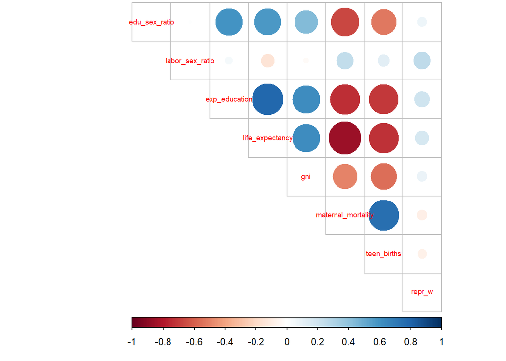

```r
corrplot(cor(human), method = "circle", type = "upper", cl.pos = "b", tl.pos = "d", tl.cex = 0.6)
```

### Princpial component analysis (PCA)

I will first experiment PCA with unstandardized data. The results below shows that if that is performed, already the first component captures virtually 100% of the variance. This is because PCA assumes that the greater the variance of a single variable is the more important the role of that variable is in capturing the total variance in the data. Because gross national income (GNI) is completely on its own scale compared to other variables in the data, that variable alone captures all of the variance. In the biplot (Fig 1.), we see that the correlation between GNI and principal componen 1 (PC1) is close to 1, thus suggesting a high importance of GNI to the model.

```r
cap2 <- "ldkfjöalskd"

# pca with unstandardized data
pca_human1 <- prcomp(human)
summary(pca_human1)$importance %>% round(digits = 1)
```

```
##                            PC1   PC2  PC3  PC4 PC5 PC6 PC7 PC8
## Standard deviation     18544.2 185.5 25.2 11.5 3.8 1.6 0.2 0.2
## Proportion of Variance     1.0   0.0  0.0  0.0 0.0 0.0 0.0 0.0
## Cumulative Proportion      1.0   1.0  1.0  1.0 1.0 1.0 1.0 1.0
```

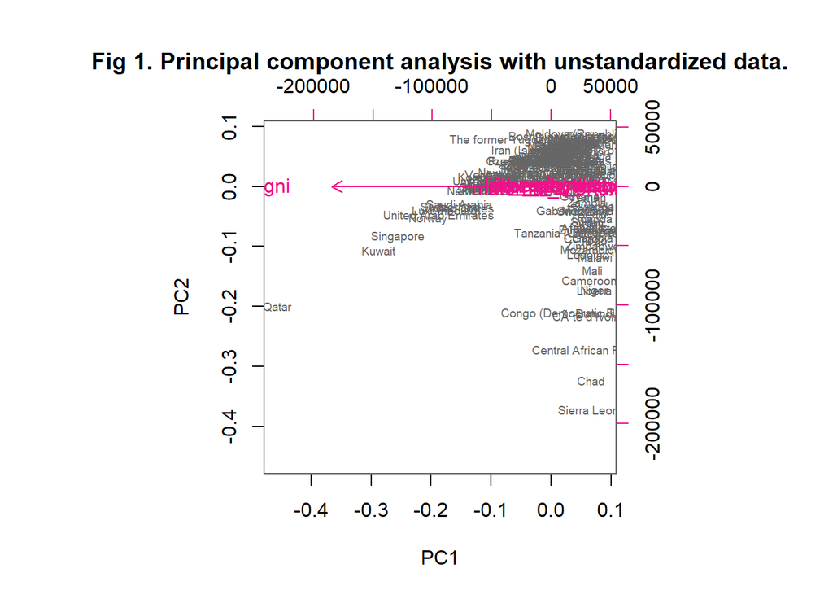

```r
biplot(pca_human1, cex = c(0.6, 1), col = c("grey40", "deeppink2"), main =  "Fig 1. Principal component analysis with unstandardized data.", caption = cap2)
```

Fig 2. present the results of PCA with standardized data. Comparing Fig. 2 with Fig 1. shows the benefit of stadardizing the data: results are different and now PCA makes sense.

The first two pricipal components could be labelled as “socioeconomic development” (PC1) and “gender equity” (PC2). The first principal component suggests that measures of education level, health, and economic development of a country are positively correlated with each other (or negatively when observing bad health, i.e. maternal mortality, and teenage childbirths).

The other principal component suggests that elements of gender equity, women’s represenation in parliament and the ratio between women and men in working life, are positively correlated. However, this data suggets that socioeconomic development and gender equity are separate phenomena, and that women’s education is related to improved health, better education, and economic development, not so much to gender equity. Women’s education level is not thus necessarily alone a sufficient marker of gender equity.

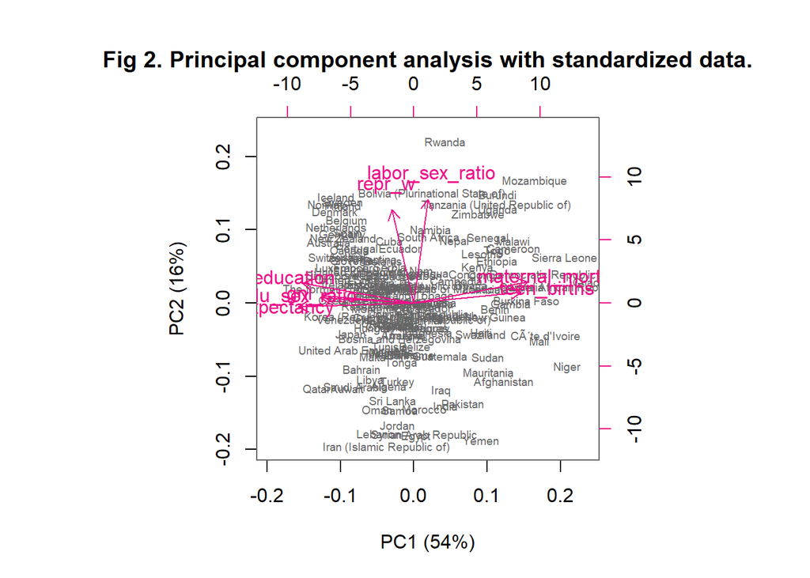

```r
# standarized data and pca with it
human_std <- scale(human)
pca_human2 <- prcomp(human_std)

# biplot axis titles
s <- summary(pca_human2)
pca_pr <- round(1*s$importance[2, ], digits = 2) * 100
pc_lab <- paste0(names(pca_pr), " (", pca_pr, "%)")

# draw a biplot
biplot(pca_human2, cex = c(0.6, 1), col = c("grey40", "deeppink2"), xlab = pc_lab[1], ylab = pc_lab[2], main =  "Fig 2. Principal component analysis with standardized data.")
```

### Multiple correspondence analysis (MCA)

I use data on tea consumption of 300 persons and select four variables for analysis. The descriptive data are presented below. It shows that most common freaquency of tea consumption is twice a day. There are people from all age groups, genders, and socioeconomic status in the data.

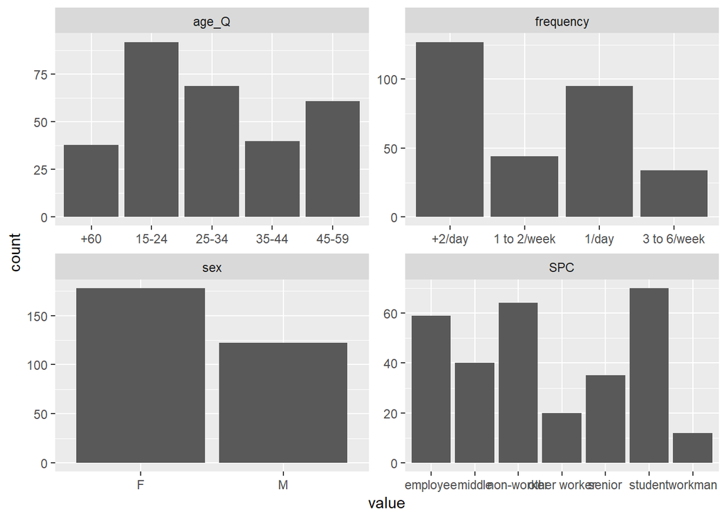

```r
library(FactoMineR)

data(tea)

tea <- as.tibble(tea)

tea_keep <- c("sex", "SPC", "age_Q", "frequency")

tea_time <- tea %>% select(tea_keep)

gather(tea_time) %>% ggplot(aes(value)) + geom_bar() + facet_wrap("key", scales = "free")
```

Below are the results from MCA. The analysis suggested 14 dimensions solution. The first two dimentions explained 13 % and 12% of the variance, respectively. The point of my analysis was to check if there is a tea consuption pattern that is shaped by sociodemographic characteristcs. The results, however, do not reveal any obvious patterns, suggesting that the chosen characteristics are unrelated to the frequency of tea consumption.

```r
mca <- MCA(tea_time, graph = F)

summary(mca)
```

```
##
## Call:
## MCA(X = tea_time, graph = F)
##
##
## Eigenvalues
##                        Dim.1   Dim.2   Dim.3   Dim.4   Dim.5   Dim.6
## Variance               0.450   0.431   0.320   0.291   0.283   0.275
## % of var.             12.849  12.318   9.141   8.328   8.072   7.859
## Cumulative % of var.  12.849  25.167  34.309  42.636  50.708  58.568
##                        Dim.7   Dim.8   Dim.9  Dim.10  Dim.11  Dim.12
## Variance               0.259   0.245   0.229   0.210   0.203   0.149
## % of var.              7.394   6.997   6.543   6.012   5.787   4.268
## Cumulative % of var.  65.961  72.958  79.501  85.513  91.301  95.569
##                       Dim.13  Dim.14
## Variance               0.084   0.071
## % of var.              2.396   2.035
## Cumulative % of var.  97.965 100.000
##
## Individuals (the 10 first)
##                 Dim.1    ctr   cos2    Dim.2    ctr   cos2    Dim.3    ctr
## 1            |  1.010  0.756  0.246 | -0.220  0.037  0.012 | -0.239  0.059
## 2            |  0.573  0.243  0.099 | -0.046  0.002  0.001 | -0.921  0.883
## 3            |  0.289  0.062  0.017 | -0.015  0.000  0.000 | -0.866  0.781
## 4            | -0.546  0.221  0.130 | -0.638  0.315  0.178 |  0.641  0.427
## 5            |  0.416  0.128  0.064 | -0.102  0.008  0.004 | -0.473  0.233
## 6            | -0.546  0.221  0.130 | -0.638  0.315  0.178 |  0.641  0.427
## 7            |  1.026  0.781  0.180 | -0.115  0.010  0.002 | -0.200  0.042
## 8            |  0.420  0.131  0.036 | -0.240  0.045  0.012 | -0.646  0.434
## 9            |  0.886  0.582  0.186 | -0.104  0.008  0.003 | -0.231  0.056
## 10           |  0.886  0.582  0.186 | -0.104  0.008  0.003 | -0.231  0.056
##                cos2
## 1             0.014 |
## 2             0.256 |
## 3             0.150 |
## 4             0.179 |
## 5             0.083 |
## 6             0.179 |
## 7             0.007 |
## 8             0.085 |
```

[output cut: 18 more lines]

```
## employee      -3.740 |  -0.245   0.921   0.015  -2.094 |
## middle        -0.977 |  -0.930   9.012   0.133  -6.308 |
## non-worker    15.319 |   0.337   1.888   0.031   3.031 |
## other worker  -2.038 |   0.017   0.002   0.000   0.079 |
## senior        -1.375 |  -0.089   0.072   0.001  -0.560 |
## student       -7.298 |   0.219   0.872   0.015   2.086 |
## workman       -2.144 |   1.465   6.706   0.089   5.170 |
## 15-24         -7.060 |   0.148   0.522   0.010   1.698 |
##
## Categorical variables (eta2)
##                Dim.1 Dim.2 Dim.3
## sex          | 0.238 0.013 0.319 |
## SPC          | 0.761 0.828 0.249 |
## age_Q        | 0.704 0.822 0.512 |
## frequency    | 0.095 0.062 0.199 |
```

Below is the MCA’s two first dimensions plotted. The second dimension (Dim2) relates non-worker status and age 60+ with each other, but not with any tea consumption frequency.

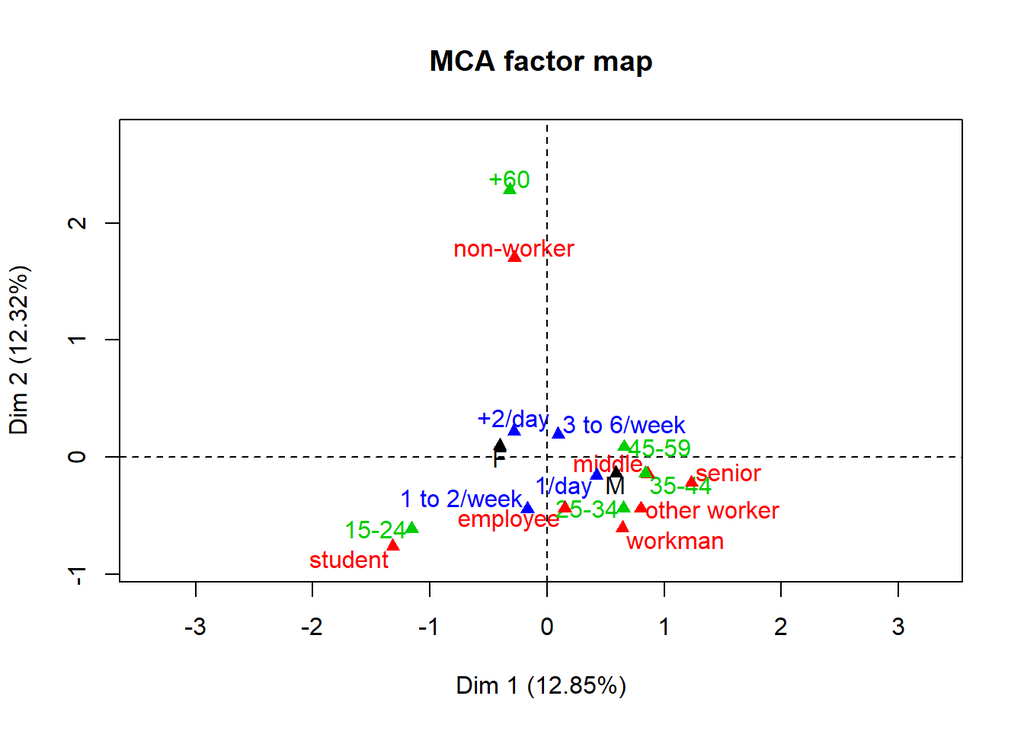

```r
plot(mca, invisible = c("ind"), habillage = "quali")
```